# Third attempt at generating data

Gustavo Garcia-Franceschini

2024-02-25

# Treatment Assignment

Here, I assign treatment, generate from uniform distribution and define parameters. Later parts of the project could explore different parameters.

```r
# 0 = control; 1 = treat
treat = c(rep(0, 500), rep(1,500))

set.seed(42)
#random U
u = runif(1000)

#treatment effect
beta = -0.5

#coefficients
lambda = 2
alpha = 3
```

# Proportional Data

Here, we produce our data from the proportional assumption. Notice the only difference in the distributions of the two groups is the factor of 1/exp(beta).

```r
proportional = tibble(

  treat = treat,

  u = u,

  t = 1/(lambda^(1/alpha)) * (-log(1-u)/exp(beta*treat))^(1/alpha),

  event = T
)
```

Here, we can see the log-rank test correctly rejects the Null (that the two groups come from the same distribution.)

```r
logrank.test(proportional$t, proportional$event, proportional$treat,
             rho = 0, gamma = 0 )
```

```
## Call:
## logrank.test(time = proportional$t, event = proportional$event,
##     group = proportional$treat, rho = 0, gamma = 0)
##
##     N Observed Expected (O-E)^2/E (O-E)^2/V
## 1 500      500      386      33.6      57.7
## 2 500      490      604      21.5      57.7
##
##  Chisq= 57.7  on 1 degrees of freedom, p= 3e-14
##  rho   =  0 gamma =  0
```

```r
logrank.test(proportional$t, proportional$event, proportional$treat,
             rho = 0, gamma = 1 )
```

```
## Call:
## logrank.test(time = proportional$t, event = proportional$event,
##     group = proportional$treat, rho = 0, gamma = 1)
##
##     N Observed Expected (O-E)^2/E (O-E)^2/V
## 1 500      500      386      33.6       203
## 2 500      490      604      21.5       203
##
##  Chisq= 48  on 1 degrees of freedom, p= 4e-12
##  rho   =  0 gamma =  1
```

```r
logrank.test(proportional$t, proportional$event, proportional$treat,
             rho = 1, gamma = 0 )
```

```
## Call:
## logrank.test(time = proportional$t, event = proportional$event,
##     group = proportional$treat, rho = 1, gamma = 0)
##
##     N Observed Expected (O-E)^2/E (O-E)^2/V
## 1 500      500      386      33.6       157
## 2 500      490      604      21.5       157
##
##  Chisq= 41.6  on 1 degrees of freedom, p= 1e-10
##  rho   =  1 gamma =  0
```

```r
logrank.maxtest(proportional$t, proportional$event, proportional$treat)
```

```
## Call:
## logrank.maxtest(time = proportional$t, event = proportional$event,
##     group = proportional$treat)
##
##  Two sided p-value = 3.63e-14 (Bonferroni corrected: 9.23e-14)
##
##  Individual weighted log-rank tests:
##   Test    z        p
## 1    1 7.60 3.08e-14
## 2    2 6.93 4.28e-12
## 3    3 6.45 1.12e-10
```

```r
s = survival::survfit(survival::Surv(t, event) ~ treat, data = proportional)
```

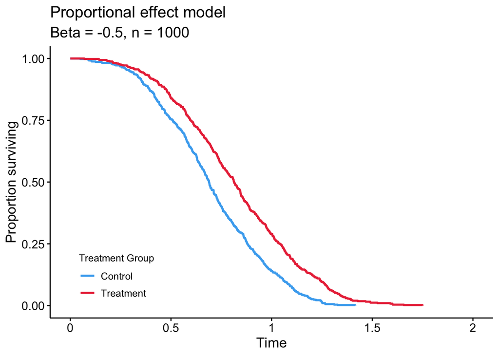

```r
ggsurvplot(s, conf.int = F, pval = FALSE, risk.table = FALSE,
    legend.labs=c("Control", "Treatment"),
    legend = c(0.15, 0.15),
    legend.title = "Treatment Group",
    palette=c("#48ACF0", "#EA3546"),
    xlab = "Time",
    ylab = "Proportion surviving",
    title = "Proportional effect model",
    subtitle = "Beta = -0.5, n = 1000",)
```

# Effect increases

Here, both treatment groups are sampled from the same distribution, up until time t_0. If the individual is alive by time t, the treatment activates (if they were assigned treatment). Future research can look at different values of t_0.

```r
t_0 = 1.05

increases = tibble(

  treat = treat,

  u = u,

  t = 1/(lambda^(1/alpha)) * (-log(1-u)/exp(beta*0))^(1/alpha), #force treat=0

  event = T
)
```

```r
increases = increases %>%
  mutate(
    t = case_when(

      t < t_0 ~ t,

      t >= t_0 ~ 1/(lambda^(1/alpha)) * (-log(1-u)/exp(beta*treat))^(1/alpha)

    )
  )
```

Here, we can see that the log-rank test with the proportional assumption incorrectly fails to reject the Null.

```r
logrank.test(increases$t, increases$event, increases$treat,
             rho = 0, gamma = 0 )
```

```
## Call:
## logrank.test(time = increases$t, event = increases$event, group = increases$treat,
##     rho = 0, gamma = 0)
##
##     N Observed Expected (O-E)^2/E (O-E)^2/V
## 1 500      500      471      1.80      3.58
## 2 500      490      519      1.64      3.58
##
##  Chisq= 3.6  on 1 degrees of freedom, p= 0.06
##  rho   =  0 gamma =  0
```

```r
logrank.test(increases$t, increases$event, increases$treat,
             rho = 0, gamma = 1 )
```

```
## Call:
## logrank.test(time = increases$t, event = increases$event, group = increases$treat,
##     rho = 0, gamma = 1)
##
##     N Observed Expected (O-E)^2/E (O-E)^2/V
## 1 500      500      471      1.80      11.9
## 2 500      490      519      1.64      11.9
##
##  Chisq= 10.8  on 1 degrees of freedom, p= 0.001
##  rho   =  0 gamma =  1
```

```r
logrank.test(increases$t, increases$event, increases$treat,
             rho = 1, gamma = 0)
```

```
## Call:
## logrank.test(time = increases$t, event = increases$event, group = increases$treat,
##     rho = 1, gamma = 0)
##
##     N Observed Expected (O-E)^2/E (O-E)^2/V
## 1 500      500      471      1.80      10.2
## 2 500      490      519      1.64      10.2
##
##  Chisq= 0  on 1 degrees of freedom, p= 0.9
##  rho   =  1 gamma =  0
```

```r
logrank.maxtest(increases$t, increases$event, increases$treat)
```

```
## Call:
## logrank.maxtest(time = increases$t, event = increases$event,
##     group = increases$treat)
##
##  Two sided p-value = 0.00231 (Bonferroni corrected: 0.00305)
##
##  Individual weighted log-rank tests:
##   Test     z       p
## 1    1 1.891 0.05859
## 2    2 3.285 0.00102
## 3    3 0.149 0.88164
```

```r
s = survival::survfit(survival::Surv(t, event) ~ treat, data = increases)
```

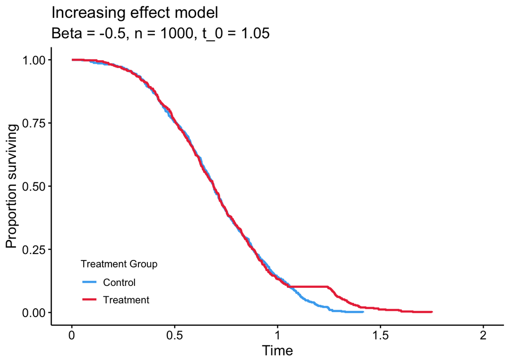

```r
ggsurvplot(s, conf.int = F, pval = FALSE, risk.table = FALSE,
    legend.labs=c("Control", "Treatment"),
    legend = c(0.15, 0.15),
    legend.title = "Treatment Group",
    palette=c("#48ACF0", "#EA3546"),
    xlab = "Time",
    ylab = "Proportion surviving",
    title = "Increasing effect model",
    subtitle = "Beta = -0.5, n = 1000, t_0 = 1.05")
```

#Decreases

Here, we first sample using the treatment effect. If the individual reaches time t_0, the effect diminishes. Further research can look at changing t_0.

```r
t_0 = 0.8
decreases = tibble(

  treat = treat,

  u = u,

  t = 1/(lambda^(1/alpha)) * (-log(1-u)/exp(beta*treat))^(1/alpha),

  event = T
)
```

```r
decreases = decreases %>%
  mutate(
    t = case_when(

      t < t_0 ~ t,

      t >= t_0 ~ 1/(lambda^(1/alpha)) * (-log(1-u)/exp(beta*0))^(1/alpha)

    )
  )
```

Here, we can see that the log-rank test with the proportional assumption incorrectly fails to reject the Null.

```r
logrank.test(decreases$t, decreases$event, decreases$treat,
             rho = 0, gamma = 0 )
```

```
## Call:
## logrank.test(time = decreases$t, event = decreases$event, group = decreases$treat,
##     rho = 0, gamma = 0)
##
##     N Observed Expected (O-E)^2/E (O-E)^2/V
## 1 500      500      482     0.639      1.24
## 2 500      499      517     0.597      1.24
##
##  Chisq= 1.2  on 1 degrees of freedom, p= 0.3
##  rho   =  0 gamma =  0
```

```r
logrank.test(decreases$t, decreases$event, decreases$treat,
             rho = 1, gamma = 0 )
```

```
## Call:
## logrank.test(time = decreases$t, event = decreases$event, group = decreases$treat,
##     rho = 1, gamma = 0)
##
##     N Observed Expected (O-E)^2/E (O-E)^2/V
## 1 500      500      482     0.639      3.71
## 2 500      499      517     0.597      3.71
##
##  Chisq= 8  on 1 degrees of freedom, p= 0.005
##  rho   =  1 gamma =  0
```

```r
logrank.test(decreases$t, decreases$event, decreases$treat,
             rho = 0, gamma = 0 )
```

```
## Call:
## logrank.test(time = decreases$t, event = decreases$event, group = decreases$treat,
##     rho = 0, gamma = 0)
##
##     N Observed Expected (O-E)^2/E (O-E)^2/V
## 1 500      500      482     0.639      1.24
## 2 500      499      517     0.597      1.24
##
##  Chisq= 1.2  on 1 degrees of freedom, p= 0.3
##  rho   =  0 gamma =  0
```

```r
logrank.maxtest(decreases$t, decreases$event, decreases$treat)
```

```
## Call:
## logrank.maxtest(time = decreases$t, event = decreases$event,
##     group = decreases$treat)
##
##  Two sided p-value = 0.0103 (Bonferroni corrected: 0.0141)
##
##  Individual weighted log-rank tests:
##   Test      z       p
## 1    1  1.115 0.26495
## 2    2 -0.907 0.36461
## 3    3  2.827 0.00469
```

```r
s = survival::survfit(survival::Surv(t, event) ~ treat, data = decreases)
```

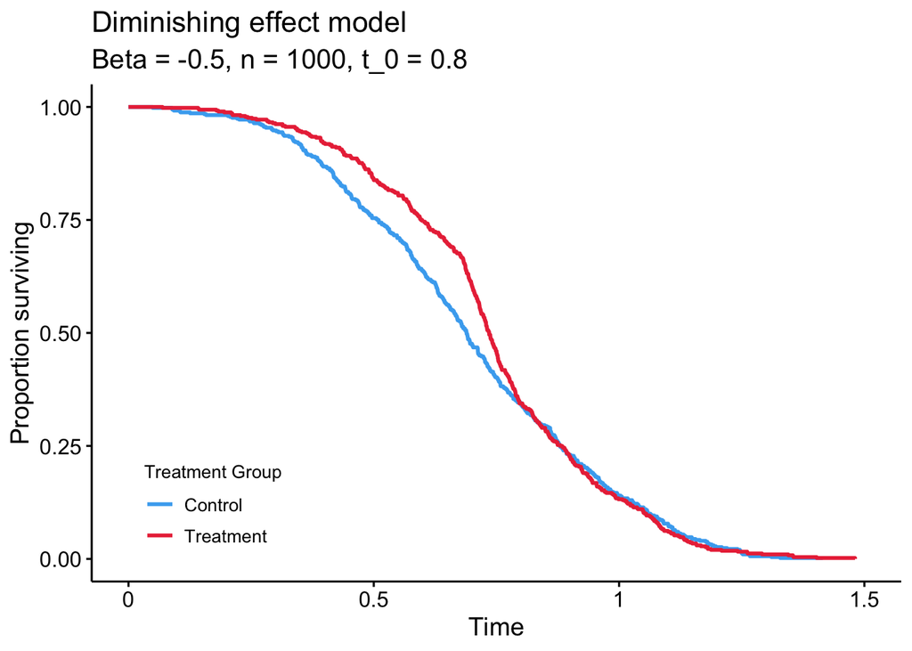

```r
ggsurvplot(s, conf.int = F, pval = FALSE, risk.table = FALSE,
    legend.labs=c("Control", "Treatment"),
    legend = c(0.15, 0.15),
    legend.title = "Treatment Group",
    palette=c("#48ACF0", "#EA3546"),
    xlab = "Time",
    ylab = "Proportion surviving",
    title = "Diminishing effect model",
    subtitle = "Beta = -0.5, n = 1000, t_0 = 0.8")
```

Type I Error and Power in 1000 simulations

See if results change with varying sample sizes

Try different t_0

This project assumes no censuring or truncation